# Gentle Introduction to R Shiny

# server

Apart from the HTML elements that we have on the ui function, other objects are outputs generated from the server side.For example the *plotlyOutput()* in this case.  
So basically what happens is, we create an object with an id on the ui side and then the code to generate the object sits in the server function. The back and forth communication between the ui and the server is made possible through the id which should be unique for each object and the ui and server functions which render the object.

The diagram below illustrates this concept.

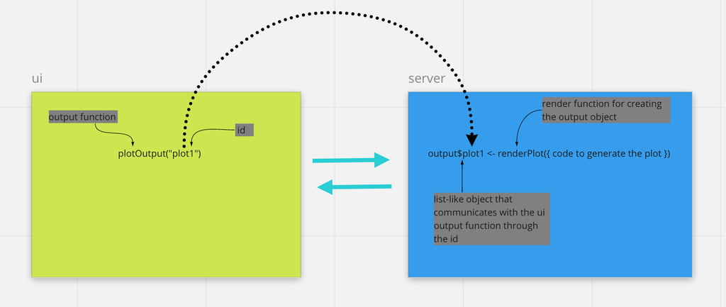

The object can be a table, a plot, a reactive text, a raw HTML etc. The image below lists some of the objects and their corresponding output and render functions just to get you started. For more on this please check out [this](https://shiny.rstudio.com/tutorial/written-tutorial/lesson4/) page, you’ll also get to understand more on reactivity.

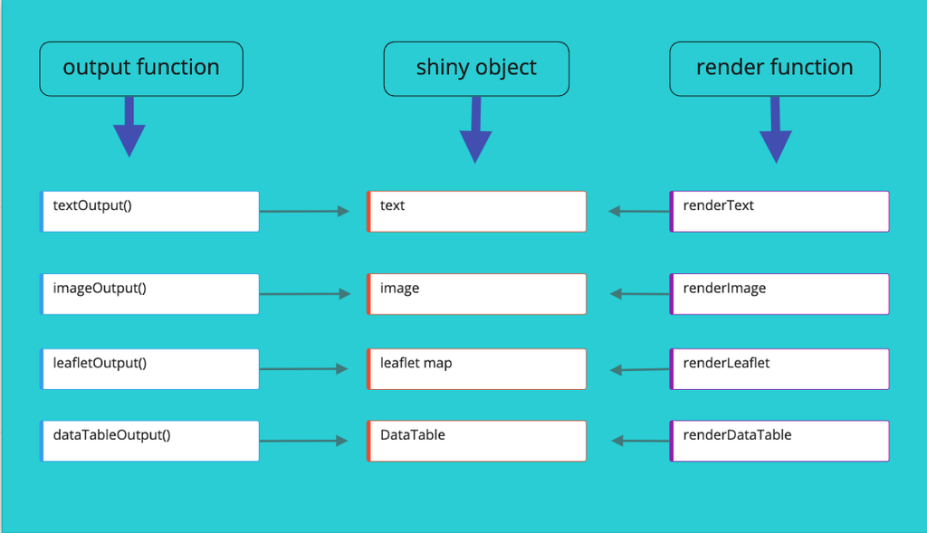

Back to our app that we were building.  
Below is the server code below that generates the two plots on our app.

```r
# Define server logic required to generate the two plots
server <- function(input, output) {


 # server code for the barplot (first object)
    output$barplot_ggplot <- renderPlotly({

        # calculating data summaries for plotting the barplot
        barplot_data <- stud_perf_melt[,.(mean_score=mean(score)),by=c("gender","subject")]

        # build the plot with plotly
           plot_ly( barplot_data,
               y = ~mean_score,
               x = ~subject,
               color = ~gender,
               text = ~paste0("Gender: ", gender, "\n", "Subject: ", subject,"\n","Mean score: ",mean_score)) %>%
           add_bars(showlegend=TRUE, hoverinfo='text' ) %>%
           layout(title="Mean gender performance",yaxis=list(title="Mean score"))
    })


  # server code for the density ridges plot (our second object)

    output$bubble_plot <- renderPlotly({

     # calculating data summaries for plotting the bubble plot
      bubbleplot_data <-  stud_perf_melt[,.(mean_score=mean(score)),by=c("race_ethnicity")]

            plot_ly(bubbleplot_data) %>%
            add_trace(x = ~reorder(race_ethnicity, mean_score),
                      y = ~mean_score,
                      size = ~mean_score,
                      color = ~race_ethnicity,
                      alpha = 4.5,
                      type = "scatter",
                      mode = "markers",
                      marker = list(symbol = 'circle', sizemode = 'diameter',
                                    line = list(width = 2, color = '#FFFFFF'), opacity=2.4)) %>%
            add_text(x = ~reorder(race_ethnicity, -mean_score),
                     y = ~race_ethnicity, text = ~mean_score,
                     showarrow = FALSE,
                     color = I("black")) %>%
            layout(
                showlegend = FALSE,
                title="Mean score with respect to ethnic groups",
                xaxis = list(
                    title = "Race/Ethnic group"
                ),
                yaxis = list(
                    title = "Mean score"
                )
            )
    })

})
```